# HPAStainR vs Single Cell Data

Tim Nieuwenhuis

8/12/2020

## Install HPAStainR and load other packages and functions

```r
if (!requireNamespace("BiocManager", quietly = TRUE))
    install.packages("BiocManager")

# The following initializes usage of Bioc devel
BiocManager::install(version='devel')

BiocManager::install("HPAStainR")

library(tidyverse)
library(HPAStainR)
library(R.utils)
library(ggpubr)
getURL <- function(URL, FUN, ..., N.TRIES = 1L) {
        N.TRIES <- as.integer(N.TRIES)
        stopifnot(length(N.TRIES) == 1L, !is.na(N.TRIES))

        while (N.TRIES > 0L) {
            result <- tryCatch(FUN(URL, ...), error = identity)
            if (!inherits(result, "error"))
                break
            N.TRIES <- N.TRIES - 1L
        }

        if (N.TRIES == 0L) {
            stop("'getURL()' failed:", "\n  URL: ", URL, "\n  error: ",
                conditionMessage(result))
        }

        result
    }
```

## Load HPA data

Using HPAStainR’s built in functions

```r
#hpa_dat <- read.table("../normal_tissue.tsv", sep = '\t', header = TRUE, stringsAsFactors = F)
hpa_dat <- HPAStainR::HPA_data_downloader("normal",save_file = F)
cancer_dat <- HPAStainR::HPA_data_downloader("cancer",save_file = F)
```

### Read in PanglaoDB

- Download the PanglaoDB marker data from their website
- Filter to protein coding genes and human relevant data

```r
temp <- tempfile()
getURL(URL = "https://panglaodb.se/markers/PanglaoDB_markers_27_Mar_2020.tsv.gz",
    FUN = download.file, destfile = temp)
```

```
## [1] 0
```

```r
dat <- read.table(gunzip(temp, "PanglaoDB_markers_27_Mar_2020.tsv.gz", overwrite = T), sep = "\t",
                  header = TRUE, stringsAsFactors = FALSE)
unlink(temp)


# download.file("https://panglaodb.se/markers/PanglaoDB_markers_27_Mar_2020.tsv.gz",
#               "PanglaoDB_markers_27_Mar_2020.tsv.gz")
# dat <- read.table(gunzip("PanglaoDB_markers_27_Mar_2020.tsv.gz", overwrite = T), sep = "\t",
#                   header = TRUE, stringsAsFactors = FALSE)


#dat <- read.table("PanglaoDB_markers_27_Mar_2020.tsv", sep = "\t", header = T, stringsAsFactors = F)

#See data organization
knitr::kable(head(tibble(dat)))
```

| species | official.gene.symbol | cell.type | nicknames | ubiquitousness.index | product.description | gene.type | canonical.marker | germ.layer | organ | sensitivity_human | sensitivity_mouse | specificity_human | specificity_mouse |
| --- | --- | --- | --- | --- | --- | --- | --- | --- | --- | --- | --- | --- | --- |
| Mm Hs | CTRB1 | Acinar cells | CTRB | 0.017 | chymotrypsinogen B1 | protein-coding gene | 1 | Endoderm | Pancreas | 1.000000 | 0.957143 | 0.0006289 | 0.0159201 |
| Mm Hs | KLK1 | Acinar cells | Klk6 | 0.013 | kallikrein 1 | protein-coding gene | 1 | Endoderm | Pancreas | 0.833333 | 0.314286 | 0.0050314 | 0.0128263 |
| Mm Hs | RBPJL | Acinar cells | RBP-L\|SUHL\|RBPSUHL | 0.001 | recombination signal binding protein for immunoglobulin kappa J region like | protein-coding gene | 1 | Endoderm | Pancreas | 0.000000 | 0.000000 | 0.0000000 | 0.0000000 |
| Mm Hs | PTF1A | Acinar cells | PTF1-p48\|bHLHa29 | 0.001 | pancreas associated transcription factor 1a | protein-coding gene | 1 | Endoderm | Pancreas | 0.000000 | 0.157143 | 0.0006289 | 0.0007734 |
| Mm | TRY4 | Acinar cells | NA | 0.007 | trypsin 4 | protein coding gene | 1 | Endoderm | Pancreas | NA | NA | NA | NA |
| Mm Hs | CELA3A | Acinar cells | ELA3\|ELA3A | 0.001 | chymotrypsin like elastase family member 3A | protein-coding gene | 1 | Endoderm | Pancreas | 0.833333 | 0.128571 | 0.0000000 | 0.0000000 |

```r
#Remove mouse data, product description, and nickname column
dat <- dat %>% select(-ends_with("mouse"), -nicknames, -product.description) %>%
  #protein coding only and mouse exclusive
  filter(species != "Mm",gene.type == "protein-coding gene" | gene.type == "protein coding gene") %>%
  #Make data more easily jive with hpastainr such as lungs vs lung
  mutate(organ = ifelse(organ == "Lungs", "Lung", organ),
         organ = ifelse(organ == "Heart", "Heart Muscle", organ)) %>%
  #make comprable column to hpastainr
  mutate(stainr_col = paste0(toupper(organ), " ", tolower(cell.type)))
```

## The for loop that runs PanglaoDB through HPAStainR

Below is the main experiment which is a for loop which does the following

- Selects a cell type from PanglaoDB
- Runs the cell type’s gene list through HPAStainR’s main function only using normal tissue
- Take top results from the output and save them
- Then find and save the top result for the specific organ of interest (the organ where the cell type comes from). When an exact match fails to exist a pathologist selected the closest possible tissue.
- Generate the confidence score
- Write out results to a csv file

```r
#Get a list of panglao cell types
groupings <- unique(dat$stainr_col)

#This is used if trouble shooting
#cell_type <- groupings[1]

#Initiate df that will be added to via the loop
final_df <- NULL
#Use this to catch dropped cell types without staining
no_stain <- NULL

#For loop through panglao cell types to run them through HPAStainR
for (cell_type in groupings) {

  #Subset out data to just cell type of interest
  sub_dat <- dat %>% filter(stainr_col == cell_type)
  #Pull out the list of genes
  genes <- sub_dat$official.gene.symbol
  #Run HPAStainR
  stain_result <- HPAStainR(gene_list = genes,hpa_dat = hpa_dat, cancer_analysis = "normal", csv_names = T)

  stain_result

  if (is.na(stain_result[1,2])) {
    no_stain <- c(no_stain, cell_type)
    next
  }

  #Make a filter to get top stainr result from a tissue
  stain_result  <- stain_result %>%
    mutate(tissue = str_sub(cell_type, start = 1, end = (str_locate(cell_type,"-"))[,1]  -2),
           stained_count = str_count(detected_proteins,",") + 1)

  #Top results of HPAStainR
  top_result <- stain_result$cell_type[1]
  top_stain <- stain_result$staining_score[1]
  top_pval <- stain_result$p_val[1]
  top_adj_pval <- stain_result$p_val_adj[1]

  ##Below code is used to match tissue types from panglao and HPA and then pull
  #the topped matched hit

  #normal
  sub_stain <- stain_result %>% filter(tissue == toupper(unique(sub_dat$organ)))


  if (is.na(unique(sub_dat$organ))) {
    sub_dat$organ <- ""
  }

  #GI tract
  if ("GI TRACT" == toupper(unique(sub_dat$organ))) {

    sub_stain <- stain_result %>% filter(tissue %in% c("COLON", "DUODENUM", "RECTUM", "SMALL INTESTINE"))
  }

  #Blood brain barrier
  if ("BRAIN" == toupper(unique(sub_dat$organ)) |
      "endothelial cells (blood brain barrier)" == tolower(unique(sub_dat$cell.type))) {
    #Brain
    sub_stain <- stain_result %>% filter(tissue %in% c("CAUDATE",
                                                       "CEREBELLUM",
                                                       "CEREBRAL CORTEX",
                                                       "CHOROID PLEXUS",
                                                       "DORSAL RAPHE",
                                                       "HIPPOCAMPUS",
                                                       "HYPOTHALAMUS",
                                                       "PITUITARY GLAND",
                                                       "SUBSTANTIA NIGRA"))
    }
  #Eye
      if ("EYE" == toupper(unique(sub_dat$organ))) {

    sub_stain <- stain_result %>% filter(tissue %in% c("RETINA"))
      }
  #Breast
   if ("MAMMARY GLAND" == toupper(unique(sub_dat$organ))) {

    sub_stain <- stain_result %>% filter(tissue %in% c("BREAST",
                                                       "LACTATING BREAST"))
    }

    #reproductive
   if ("REPRODUCTIVE" == toupper(unique(sub_dat$organ))) {

    sub_stain <- stain_result %>% filter(tissue %in% c("TESTIS",
                                                       "OVARY"))
   }
      #adrenal
   if ("ADRENAL GLANDS" == toupper(unique(sub_dat$organ))) {

    sub_stain <- stain_result %>% filter(tissue %in% c("ADRENAL GLAND"))
   }

        #throid
   if ("THYROID" == toupper(unique(sub_dat$organ))) {

    sub_stain <- stain_result %>% filter(tissue %in% c("THYROID GLAND"))
   }

          #ENDOTHELIAL
   if ("endothelial cells (aorta)" == tolower(unique(sub_dat$cell.type))) {

    sub_stain <- stain_result %>% filter(tissue %in% c("COLON"))
    }


        #bone and blood
   if ("BONE" == toupper(unique(sub_dat$organ)) | "BLOOD" == toupper(unique(sub_dat$organ))) {

    sub_stain <- stain_result %>% filter(tissue %in% c("BONE MARROW"))
   }

     if ("OLFACTORY SYSTEM" == toupper(unique(sub_dat$organ))) {

    sub_stain <- stain_result %>% filter(tissue %in% c("NASOPHARYNX"))
     }

       if ("IMMUNE SYSTEM" == toupper(unique(sub_dat$organ))) {

    sub_stain <- stain_result %>% filter(tissue %in% c("BONE MARROW",
                                                       "THYMUS",
                                                       "LYMPH NODE",
                                                       "TONSIL"))
    }


   if ("CONNECTIVE TISSUE" == toupper(unique(sub_dat$organ))) {
    #Brain
    sub_stain <- stain_result %>% filter(tissue %in% c("ADIPOSE TISSUE",
                                                       "SOFT TISSUE"))
    }

  #Stores the top result from the correct tissue in an object
  top_tiss_result <- sub_stain$cell_type[1]
  top_tiss_stain <- sub_stain$staining_score[1]
  top_tiss_pval <- sub_stain$p_val[1]
  top_tiss_adj_pval <- sub_stain$p_val_adj[1]

  #Catches no found tissues
  if (nrow(sub_stain) == 0) {
    top_tiss_result <- "tissue not found"
  }

  #Number of proteins used
  proteins_used <- length(unique(sub_dat$official.gene.symbol))

  #The average N of proteins used for the top ten results (not all tissues are tested equally)
  top_10_avg_prot_tested <- mean(head(stain_result$number_of_proteins))

  #Make confidence score to account for low protein count not being taken into account

  conf_score <- ifelse(proteins_used > 50, 50, proteins_used) * 0.02 * top_stain

  #If there is not enough data to run a chi_square turn results into NA
  if (is.null(top_adj_pval)) {
    top_adj_pval =NA
    top_tiss_adj_pval =NA
     top_pval =NA
    top_tiss_pval =NA
  }

  #Make single row output dataframe to be bound to main dataframe
  temp_dat <- data.frame(cell_type,
                         conf_score,
                         proteins_used,
                         top_10_avg_prot_tested,
                         top_result, top_stain,
                         top_pval,
                         top_adj_pval,
                         top_tiss_result,
                         top_tiss_stain,
                         top_tiss_pval,
                         top_tiss_adj_pval,
                         stringsAsFactors = F)

  #Bind it
  final_df <- rbind(final_df, temp_dat)
}

knitr::kable(head(final_df))
```

| cell_type | conf_score | proteins_used | top_10_avg_prot_tested | top_result | top_stain | top_pval | top_adj_pval | top_tiss_result | top_tiss_stain | top_tiss_pval | top_tiss_adj_pval |
| --- | --- | --- | --- | --- | --- | --- | --- | --- | --- | --- | --- |
| PANCREAS acinar cells | 58.320 | 48 | 37.000000 | PANCREAS - exocrine glandular cells | 60.75 | <0.005 | 0.037 | PANCREAS - exocrine glandular cells | 60.75 | <0.005 | 0.037 |
| CONNECTIVE TISSUE adipocyte progenitor cells | 21.045 | 23 | 10.666667 | STOMACH - glandular cells | 45.75 | 0.018 | 1.00 | SOFT TISSUE - fibroblasts | 17.50 | 1.000 | 1.00 |
| CONNECTIVE TISSUE adipocytes | 33.750 | 116 | 74.000000 | KIDNEY - cells in tubules | 33.75 | 0.299 | 1.000 | ADIPOSE TISSUE - adipocytes | 19.75 | <0.005 | 0.042 |
| BRAIN adrenergic neurons | 10.320 | 8 | 6.333333 | ADRENAL GLAND - glandular cells | 64.50 | <0.005 | 0.08 | CAUDATE - neuronal cells | 17.50 | 1.000 | 1.00 |
| LUNG airway epithelial cells | 5.360 | 4 | 3.000000 | ESOPHAGUS - squamous epithelial cells | 67.00 | 0.035 | 1.00 | LUNG - pneumocytes | 41.25 | 1.000 | 1.00 |
| LUNG airway goblet cells | 29.000 | 25 | 19.000000 | STOMACH - glandular cells | 58.00 | <0.005 | 0.037 | LUNG - pneumocytes | 13.25 | 1.000 | 1.000 |

```r
#write.csv(final_df, "data_out/extended_table_4_final_df_output.csv", row.names = F)
```

## PanglaoDB Data summary

```r
#Comparing available cell types between Panglao and HPA
avail_hpa_tissue_cells = unique(stain_result$cell_type)
avail_pangloa_tissue_cells = unique(dat$stainr_col)

avail_hpa_tissue_cells <- c(avail_hpa_tissue_cells,
                            rep("", length(avail_pangloa_tissue_cells) - length(avail_hpa_tissue_cells)))

tissues_and_cells <- cbind(avail_hpa_tissue_cells, avail_pangloa_tissue_cells)

colnames(tissues_and_cells) <- c("Tissue - Cells in HPA", " Tissue - Cells in PanglaoDB")

#write.csv(tissues_and_cells, "panglao_v_hpa_available_cell_types.csv", row.names = F)


#Make a histogram of how many marker genes there are per cell type
summ_dat <- dat %>% group_by(cell.type) %>% summarize(genes = n())
summary(summ_dat)
```

```
##   cell.type             genes
##  Length:142         Min.   :  1.00
##  Class :character   1st Qu.: 15.00
##  Mode  :character   Median : 28.00
##                     Mean   : 41.92
##                     3rd Qu.: 51.75
##                     Max.   :216.00
```

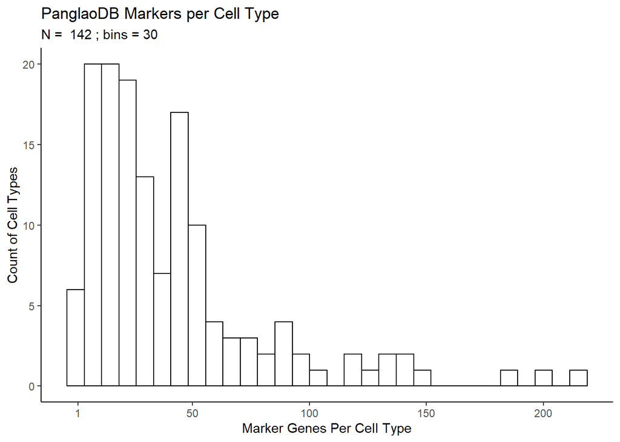

```r
ticks <- c(1, 50, 100, 150, 200)
ext_fig_4 <- ggplot(summ_dat, aes(x=genes)) +
                geom_histogram(color="black", fill="white", bins = 30) +
                xlab("Marker Genes Per Cell Type") +
                labs(title ="PanglaoDB Markers per Cell Type",
                     subtitle =  paste("N = ", nrow(summ_dat),"; bins = 30")) +
                ylab("Count of Cell Types") +
                theme_classic() + scale_x_continuous(breaks=ticks)

ext_fig_4
```

```r
ggsave("data_out/extended_figure_3_pangloa_hist.png", width = 8, height = 7)
ggsave("data_out/extended_figure_5_pangloa_hist.eps", width = 8, height = 7)
```

extended Table 2-3

```r
 ## Make new column combining cell type and tissue
    hpa_dat_2 <- hpa_dat %>%
        mutate(Tissue = gsub("[[:digit:]]+", "", Tissue),
               tissue_cell = paste0(toupper(str_trim(Tissue)),
                                    " - ",
                                    Cell.type))


low_filter_supp_2   <- hpa_dat_2 %>%
    select(Gene.name, tissue_cell, Reliability, Level) %>%
    mutate(stained = ifelse(Level %in% c("Not detected", "N/A"), 0, 1)) %>%
    unique() %>%
    group_by(Gene.name) %>% summarise(n(), stain_count = sum(stained)) %>%
    mutate(stained_per_test = stain_count/ `n()`, filter = "low" ) %>%
    rename(`Times tested` = `n()`,
           `Time stained` = stain_count,
           `Stained per tested Low` = stained_per_test) %>%
  filter(`Stained per tested Low` != 0)

low_filter_supp_2 <- low_filter_supp_2 %>%
  mutate(`Rare Low` = ifelse(`Stained per tested Low` <
                         quantile(low_filter_supp_2$`Stained per tested Low`, .25),
                       "yes", "no")) %>%
  select(Gene.name, `Stained per tested Low`, `Rare Low` )



normal_filter_supp_2   <- hpa_dat_2 %>%
    select(Gene.name, tissue_cell, Reliability, Level) %>%
    filter(Reliability %in% c("Enhanced", "Supported", "Approved")) %>%
    mutate(stained = ifelse(Level %in% c("Not detected", "N/A"), 0, 1)) %>%
      unique() %>%
    group_by(Gene.name) %>% summarise(n(), stain_count = sum(stained)) %>%
    mutate(stained_per_test = stain_count/ `n()`, filter = "normal" ) %>%
    rename(`Times tested` = `n()`,
           `Time stained` = stain_count,
           `Stained per tested Normal` = stained_per_test)

normal_filter_supp_2 <- normal_filter_supp_2 %>%
  mutate(`Rare Normal` = ifelse(`Stained per tested Normal` <
                         quantile(normal_filter_supp_2$`Stained per tested Normal`, .25),
                       "yes", "no")) %>%
  select(Gene.name, `Stained per tested Normal`, `Rare Normal` )


high_filter_supp_2   <- hpa_dat_2 %>%
    select(Gene.name, tissue_cell, Reliability, Level) %>%
    filter(Reliability %in% c("Enhanced","Supported")) %>%
    mutate(stained = ifelse(Level %in% c("Not detected", "N/A"), 0, 1)) %>%
    unique() %>%
    group_by(Gene.name) %>% summarise(n(), stain_count = sum(stained)) %>%
    mutate(stained_per_test = stain_count/ `n()`, filter = "high" ) %>%
    rename(`Times tested` = `n()`,
           `Time stained` = stain_count,
           `Stained per tested High` = stained_per_test)

high_filter_supp_2 <- high_filter_supp_2 %>%
  mutate(`Rare High` = ifelse(`Stained per tested High` <
                         quantile(high_filter_supp_2$`Stained per tested High`, .25),
                       "yes", "no")) %>%
  select(Gene.name, `Stained per tested High`, `Rare High` )


supp_table_2 <- left_join(left_join(low_filter_supp_2, normal_filter_supp_2), high_filter_supp_2) %>%
  mutate_if(is.numeric, round, 3)


#write.csv(supp_table_2, "data_out/extended_table_2_gene_rarity.csv", row.names = FALSE)
####Repeat for cancer

cancer_sub_table <- cancer_dat %>%
  select(Gene.name, Cancer, High, Medium, Low, Not.detected) %>%
  mutate(stained = High + Medium + Low, tested = stained + Not.detected) %>%
  group_by(Gene.name) %>%
  summarise(stained = sum(stained,na.rm = T),
              tested = sum(tested,na.rm = T)) %>%
  mutate(`Stained per Tested` = round(stained/tested, 3)) %>%
  filter(!is.nan(`Stained per Tested`))

cancer_sub_table <- cancer_sub_table %>%
  mutate(Rare = ifelse(`Stained per Tested` <
                         quantile(cancer_sub_table$`Stained per Tested`, .25),
                       "Yes", "No"))
#write.csv(cancer_sub_table, "extended_table_3_cancer_gene_rarity.csv", row.names = FALSE)
quantile(supp_table_2$`Stained per tested Low`, .25)
```

```
##   25%
## 0.247
```

```r
quantile(supp_table_2$`Stained per tested Normal`, .25, na.rm = T)
```

```
##   25%
## 0.176
```

```r
quantile(supp_table_2$`Stained per tested High`, .25, na.rm = T)
```

```
##   25%
## 0.068
```

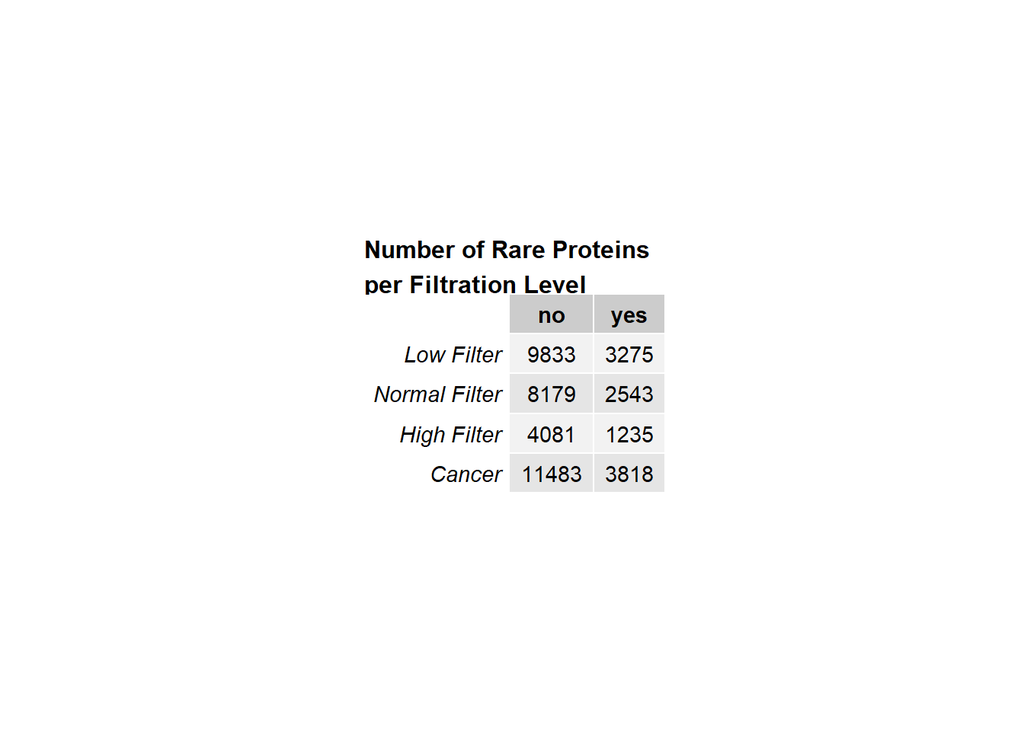

```r
rarity_table  <- rbind(table(supp_table_2$`Rare Low`),
table(supp_table_2$`Rare Normal`),
table(supp_table_2$`Rare High`),
table(cancer_sub_table$Rare))

rownames(rarity_table) <- c("Low Filter", "Normal Filter", "High Filter", "Cancer")

title <- paste0(
"Number of Rare Proteins per Filtration Level"
) %>%
  strwrap(width = 25) %>%
  paste(collapse = "\n")


ggtexttable(rarity_table) %>%
  tab_add_title(text = title, face = "bold", padding = unit(0.1, "line"))
```

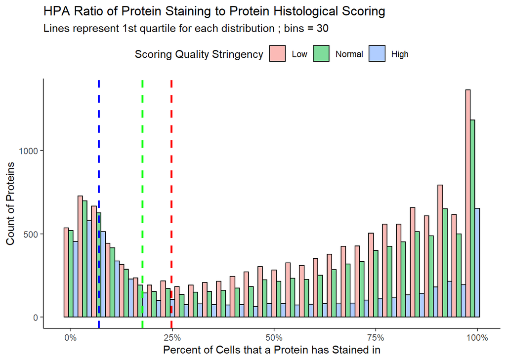

```r
library(reshape2)

normal_gene_df <- supp_table_2 %>% select(Gene.name,
                        Low = `Stained per tested Low`,
                        Normal = `Stained per tested Normal`,
                        High = `Stained per tested High`)


normal_gene_df_melt <- melt(normal_gene_df)


ext_fig_2b <- ggplot(normal_gene_df_melt, aes(x = value, fill = variable)) +
  geom_histogram(position="dodge", alpha=0.5, color = "black", bins=30) +
  geom_vline(xintercept = c(quantile(normal_gene_df$Low, .25, na.rm = TRUE),
                            quantile(normal_gene_df$Normal, .25, na.rm = TRUE),
                            quantile(normal_gene_df$High, .25, na.rm = TRUE)),
             color = c("red", "green", "blue"),
             linetype ="dashed",
             size = 1) +
            scale_x_continuous(labels = scales::percent) +
  labs(title = "HPA Ratio of Protein Staining to Protein Histological Scoring",
       subtitle = paste("Lines represent 1st quartile for each distribution","; bins = 30")) +
  xlab("Percent of Cells that a Protein has Stained in") +
  ylab("Count of Proteins") +
  scale_fill_discrete(name="Scoring Quality Stringency") +
  theme_classic() +
  theme(legend.position = "top")

ext_fig_2b
```

```r
ggsave("data_out/extended_fig_2b.png")
```

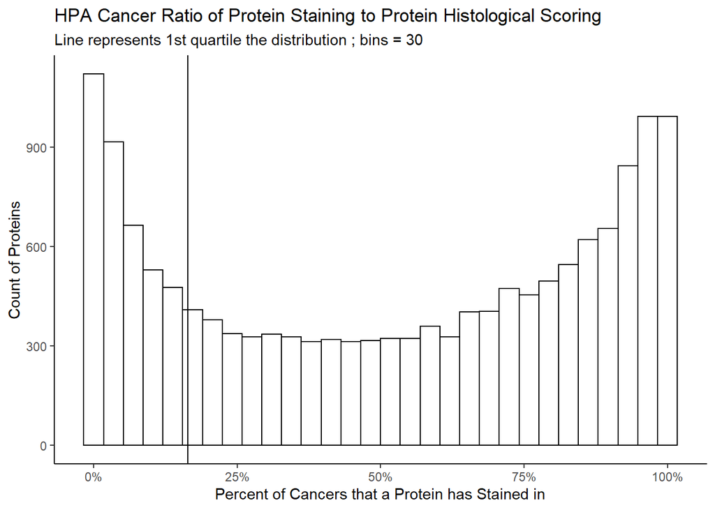

```r
## For cancer below

ext_fig_3b <- ggplot(cancer_sub_table, aes(x = `Stained per Tested`)) +
  geom_histogram(fill = "white", color = "black") +
  geom_vline(xintercept = quantile(cancer_sub_table$`Stained per Tested`,
                                   .25, na.rm = TRUE)) +
            scale_x_continuous(labels = scales::percent) +
  labs(title = "HPA Cancer Ratio of Protein Staining to Protein Histological Scoring",
       subtitle = paste("Line represents 1st quartile the distribution","; bins = 30")) +
  xlab("Percent of Cancers that a Protein has Stained in") +
  ylab("Count of Proteins") +
  theme_classic()
ext_fig_3b
```

```r
ggsave("data_out/extended_fig_3b.png")
```

Here we generate a boxplot for normal data and cancer data showing the distribution of how many cell types proteins were evaluated in, based on where they are in the above bins made by the histogram. These are Extended Figure 2 and 3 A.

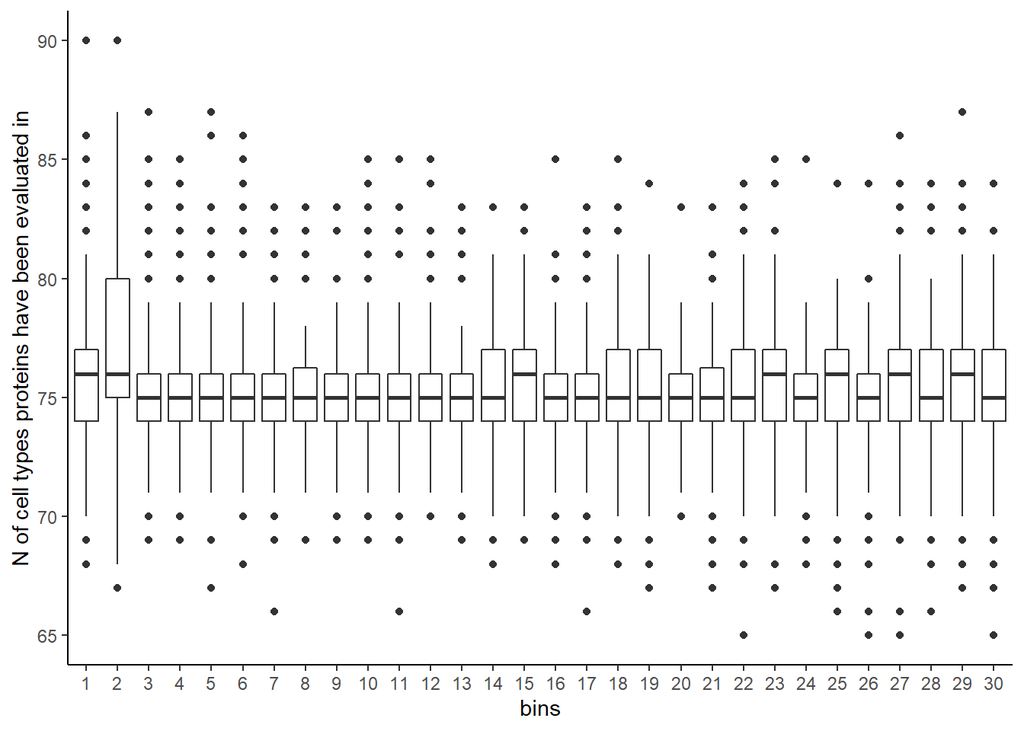

```r
normal_melt <- normal_gene_df_melt %>% filter(variable == "Normal") %>% arrange(desc(value)) %>% drop_na()
normal_melt$bins <- cut(normal_melt$value, breaks = 30)

#normal_melt$bins <- factor(normal_melt$bins, levels = rev(levels(normal_melt$bins)))

normal_prot_test   <- hpa_dat_2 %>%
    select(Gene.name, tissue_cell, Reliability, Level) %>%
    unique() %>%
    filter(Reliability %in% c("Enhanced", "Supported", "Approved")) %>%
    mutate(stained = ifelse(Level %in% c("Not detected", "N/A"), 0, 1)) %>%
    group_by(Gene.name) %>% summarise(n(), stain_count = sum(stained)) %>%
    rename(`Times tested` = `n()`,
           `Time stained` = stain_count)


normal_bins <- left_join(normal_prot_test, normal_melt) %>% drop_na()


#Rename bins


ext_fig_2a <- ggplot(normal_bins, aes(bins, `Times tested`)) +
  geom_boxplot() +
 scale_x_discrete(labels = as.character(1:30)) +
  ylab("N of cell types proteins have been evaluated in") +
  theme_classic()

ext_fig_2a
```

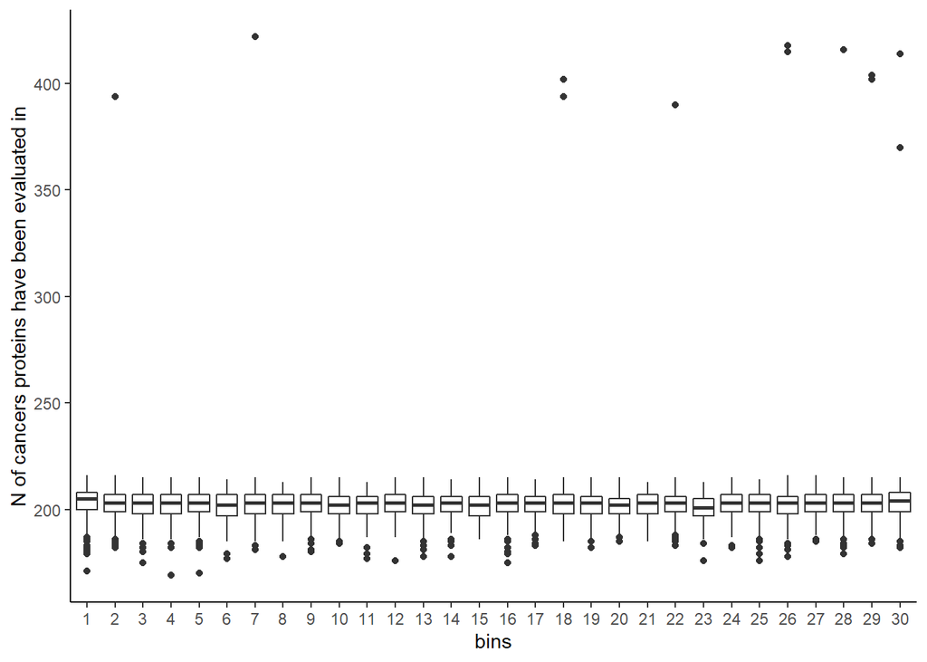

```r
ggsave("data_out/extended_fig_2a.png")

#### With cancer

cancer_melt <- cancer_sub_table %>%
  arrange(desc(`Stained per Tested`)) %>%
  drop_na()
cancer_melt$bins <- cut(cancer_melt$`Stained per Tested`, breaks = 30)

ext_fig_3a <- ggplot(cancer_melt, aes(bins, tested)) +
  geom_boxplot() +
 scale_x_discrete(labels = as.character(1:30)) +
  #coord_flip() +
  ylab("N of cancers proteins have been evaluated in") +
  theme_classic()

ext_fig_3a
```

```r
ggsave("data_out/extended_fig_3a.png")
```

## HPA Data Summary

Preparing the data

```r
#Generate data to gain an understanding of the amount of proteins tested to the amount of proteins stained

#Clean the hpa data
hpa_dat_new <- hpa_dat %>%
      mutate(Tissue = gsub('[[:digit:]]+', '', Tissue),
             tissue_cell = paste0(toupper(str_trim(Tissue))," - ", Cell.type)) %>%
      distinct()



#Generate a summary of hpa_summary
hpa_dat_sum <- hpa_dat_new %>% group_by(tissue_cell) %>%
  summarise(proteins = n(), detected = sum(!(Level %in% "Not detected")) ) %>%
  mutate(det_o_test = detected/proteins,
         amount_tested = ifelse(proteins <= 50, "\u2264 50",
                          ifelse(proteins > 50 & proteins <= 700, "51 \u2264 & \u2264 700",
                          ifelse(proteins > 700 & proteins <= 15000, "701 \u2264 & \u2264 15,000",
                                   "15,000 \u2264")))) %>%
    filter(tissue_cell != "N/A - N/A")


hpa_dat_sum$amount_tested <- factor(hpa_dat_sum$amount_tested,
                                    levels = c("\u2264 50",
                                               "51 \u2264 & \u2264 700",
                                               "701 \u2264 & \u2264 15,000",
                                               "15,000 \u2264"))

stat_mode <- function(v) {
   uniqv <- unique(v)
   uniqv[which.max(tabulate(match(v, uniqv)))]
}

stat_mode(hpa_dat_sum$proteins)
```

```
## [1] 3
```

```r
summary(hpa_dat_sum$proteins)
```

```
##    Min. 1st Qu.  Median    Mean 3rd Qu.    Max.
##       1      40   12777    7347   13296   17091
```

Extended Figure 1A

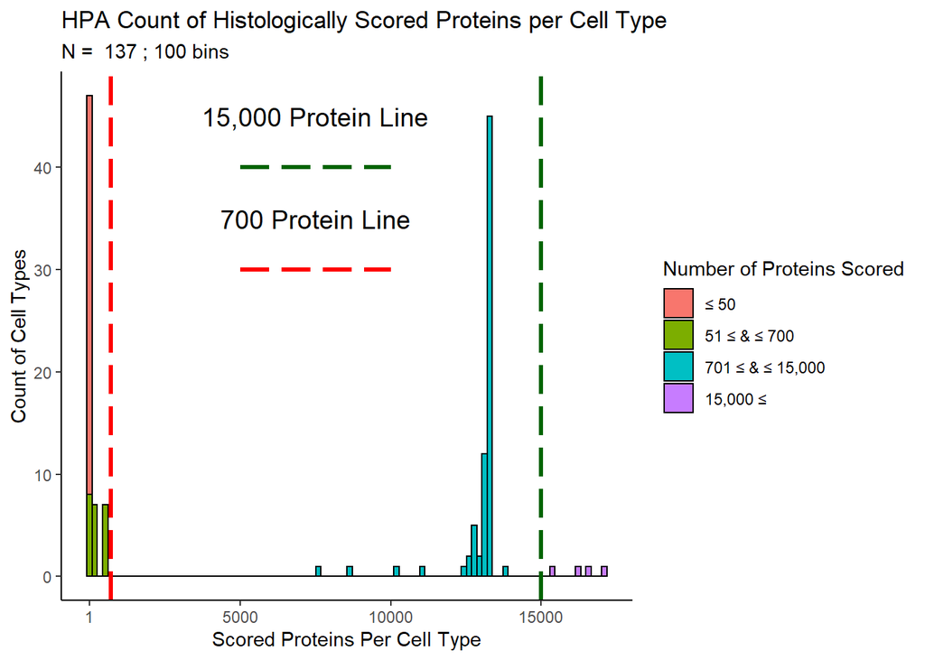

```r
ticks <- c(1, 5000, 10000, 15000)


ext_fig_1a <- ggplot(hpa_dat_sum, aes(x=(proteins), fill = amount_tested)) +
              geom_histogram(color="black", bins=100) +
              xlab("Scored Proteins Per Cell Type") +
              labs( title ="HPA Count of Histologically Scored Proteins per Cell Type",
                    subtitle = paste("N = ", nrow(hpa_dat_sum),"; 100 bins")) +
              geom_vline(xintercept= c(700, 15000),
                         linetype = c("longdash"),
                         color = c("red", "dark green"),
                         size = 1.2) +
              geom_segment(aes(x = c(5000),
                               xend = c(10000),
                               y = c(30),
                               yend = c(30)),
                           color = "red",
                           linetype = c("longdash"), size = 1.2) +
              geom_segment(aes(x = c(5000),
                               xend = c(10000),
                               y = c(40),
                               yend = c(40)),
                           color = "dark green",
                           linetype = c("longdash"),
                           size = 1.2) +
              annotate(geom="text", #angle = 90, vjust = 1.3,
                       size = 5,
                       x=c(7500, 7500),
                       y=c(35, 45),
                       label=c("700 Protein Line", "15,000 Protein Line")
                          #color="red"

                       ) +
              scale_fill_discrete(name="Number of Proteins Scored") +
              ylab("Count of Cell Types") + theme_classic() +
              scale_x_continuous(breaks=ticks)


ext_fig_1a
```

```r
ggsave("data_out/extended_figure_1a_proteins_tested.png", width = 9, height = 6)
```

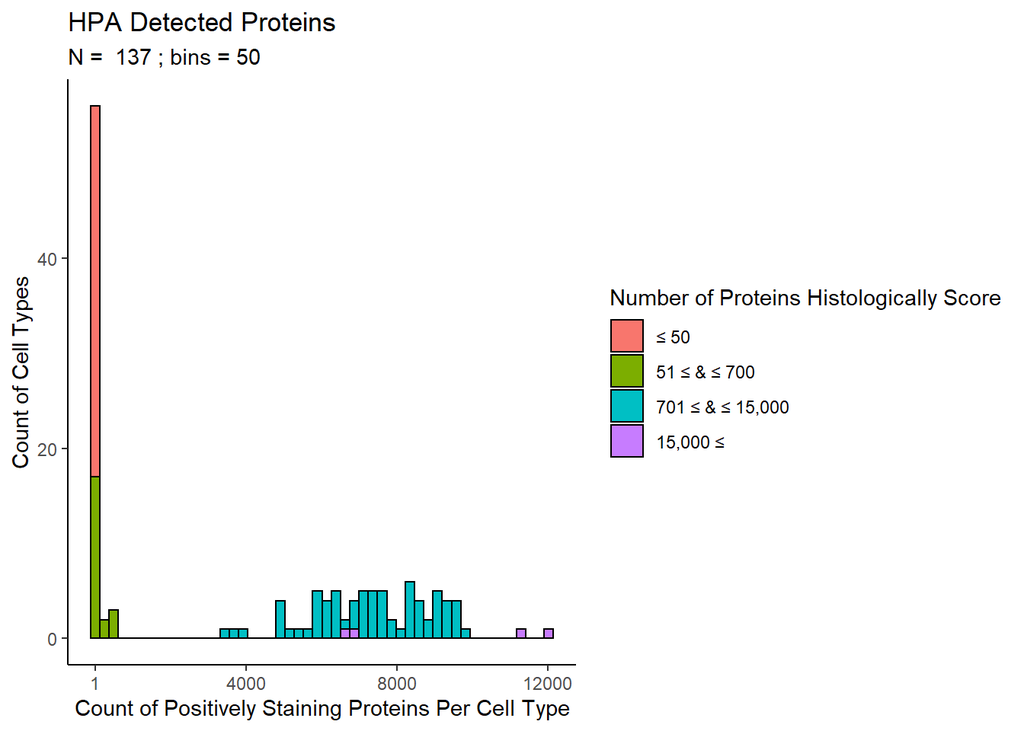

```r
ticks <- c(1, 4000, 8000, 12000)
ext_fig_1b <- ggplot(hpa_dat_sum, aes(x=detected)) +
              geom_histogram(aes(fill = amount_tested),color="black", bins=50) +
              xlab("Count of Positively Staining Proteins Per Cell Type") +
              labs(title="HPA Detected Proteins",
              subtitle = paste("N = ", nrow(hpa_dat_sum), "; bins = 50")) +
              ylab("Count of Cell Types") +
              scale_fill_discrete(name="Number of Proteins Histologically Score")+ theme_classic() +
              scale_x_continuous(breaks=ticks)

ext_fig_1b
```

```r
ggsave("data_out/extended_figure_1b_proteins_detected.png", width = 9, height = 6)
```

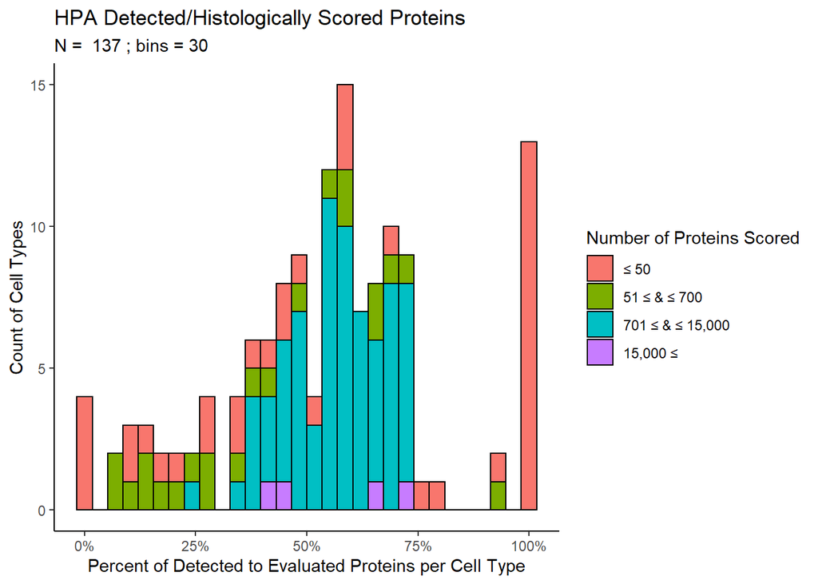

```r
ext_fig_1c <- ggplot(hpa_dat_sum, aes(x=det_o_test)) +
              geom_histogram(aes(fill =amount_tested), color="black", bins = 30) +
              xlab("Percent of Detected to Evaluated Proteins per Cell Type") +
              labs(title="HPA Detected/Histologically Scored Proteins",
                   subtitle = paste("N = ", nrow(hpa_dat_sum),"; bins = 30")) +
              ylab("Count of Cell Types") +
              scale_fill_discrete(name="Number of Proteins Scored") +
              theme_classic() +
              scale_x_continuous(labels = scales::percent)

ext_fig_1c
```

```r
ggsave("data_out/extended_figure_1c_proteins_detected_divby_tested.png", width = 9, height = 6)
```

Extended Table 1

```r
hpa_dat_sum_out <- select(hpa_dat_sum,
                          `Cell Type` = tissue_cell,
                          `Tested Proteins` = proteins,
                          `Detected Proteins` = detected,
                          `Detected Tested Ratio` = det_o_test)

#write.csv(hpa_dat_sum_out, "data_out/extended_table_1_hpa_cell_type_tested_ratio.csv",row.names = F)
```

Writing out all of the plots

```r
cairo_pdf(filename = "extended_Figures.pdf", width = 8, height = 5, onefile=T)
ext_fig_1a
ext_fig_1b
ext_fig_1c
ext_fig_2a
ext_fig_2b
ext_fig_3a
ext_fig_3b
ext_fig_4
dev.off()
```

```r
ticks <- c(1, 4000, 8000, 12000)
```

# Recapitulate McCall experiment.

The chunk below does the following: + Reads in the McCall et al. gene clusters from the GTEx lung + Runs gene cluster A and gene cluster B through HPAStainR + Prints and saves results of each analysis

```r
file_path <- "https://www.ncbi.nlm.nih.gov/pmc/articles/PMC5011060/bin/mmc3.xls"

temp = tempfile(fileext = ".xlsx")
download.file(file_path, destfile=temp, mode='wb')

lung_clust <- readxl::read_xls(temp)

supp_table_4 <- HPAStainR(lung_clust$`Cluster A`, hpa_dat = hpa_dat, cancer_dat = cancer_dat)
supp_table_5 <- HPAStainR(lung_clust$`Cluster B`, hpa_dat = hpa_dat, cancer_dat = cancer_dat)


supp_table_4
```

```
## # A tibble: 138 x 11
##    cell_type percent_high_ex~ percent_medium_~ percent_low_exp~ percent_not_det~
##    <chr>                <dbl>            <dbl>            <dbl>            <dbl>
##  1 LUNG - p~             0.2              0.1              0.1              0.6
##  2 SMALL IN~             0.15             0.15             0.05             0.65
##  3 DUODENUM~             0.15             0.1              0.05             0.7
##  4 STOMACH ~             0.15             0.07             0.1              0.68
##  5 KIDNEY -~             0.1              0.05             0.2              0.65
##  6 APPENDIX~             0.05             0.15             0.05             0.75
##  7 COLON - ~             0.05             0.1              0.15             0.7
##  8 LUNG - m~             0.05             0.1              0.15             0.7
##  9 RECTUM -~             0.05             0.1              0.15             0.7
## 10 URINARY ~             0.05             0.1              0.15             0.7
## # ... with 128 more rows, and 6 more variables: number_of_proteins <dbl>,
## #   tested_proteins <chr>, detected_proteins <chr>, staining_score <dbl>,
## #   p_val <chr>, p_val_adj <chr>
```

```r
supp_table_5
```

```
## # A tibble: 138 x 11
##    cell_type percent_high_ex~ percent_medium_~ percent_low_exp~ percent_not_det~
##    <chr>                <dbl>            <dbl>            <dbl>            <dbl>
##  1 BRONCHUS~             0.55             0.33             0.06             0.06
##  2 FALLOPIA~             0.36             0.45             0.03             0.15
##  3 NASOPHAR~             0.33             0.36             0.06             0.18
##  4 ENDOMETR~             0.03             0.11             0.3              0.56
##  5 CERVIX, ~             0.09             0.06             0.12             0.67
##  6 GALLBLAD~             0.06             0.03             0.09             0.82
##  7 STOMACH ~             0.03             0.09             0.08             0.8
##  8 COLON - ~             0.06             0.03             0.06             0.85
##  9 DUODENUM~             0.03             0.06             0.12             0.79
## 10 RECTUM -~             0.06             0.03             0.06             0.85
## # ... with 128 more rows, and 6 more variables: number_of_proteins <dbl>,
## #   tested_proteins <chr>, detected_proteins <chr>, staining_score <dbl>,
## #   p_val <chr>, p_val_adj <chr>
```

```r
#write.csv(supp_table_4, "data_out/extended_table_4_pneumocytes.csv",row.names = F)
#write.csv(supp_table_5, "data_out/extended_table_5_bronchus.csv", row.names = F)
```

The purpose of this is to show that we can recapitulate the results from the McCall paper which shows that these two cluster, A and B, are associated with pneumocytes (due to surfactants) and bronchus epithelial cells respectively. As you can see HPAStainR correctly characterizes these cell types.

Further clean up data by writing out to single XLSX file

This ended up not working so I’ll just do them as a CSV

```r
#Ext table 1
write.csv(hpa_dat_sum_out,
           file = "data_out/exteneded_table_1.csv",
            row.names = F)
#Ext table 2
write.csv(supp_table_2,
           file = "data_out/exteneded_table_2.csv",
           row.names = F)
#Ext table 3
write.csv(cancer_sub_table,
           file = "data_out/exteneded_table_3.csv",
          row.names = F)
#Ext table 4
write.csv(final_df,
           file = "data_out/exteneded_table_4.csv",
           row.names = F)
#Ext table 5
write.csv(supp_table_4,
           file = "data_out/exteneded_table_5.csv",
           row.names = F)

#Ext table 6
write.csv(supp_table_5,
           file = "data_out/exteneded_table_6.csv", row.names = F)


# #Ext table 1
# write.xlsx(hpa_dat_sum_out,
#            file = "data_out/exteneded_tables.xlsx",
#            sheetName = "Extended Table 1")
# #Ext table 2
# write.xlsx(supp_table_2,
#            file = "data_out/exteneded_tables.xlsx",
#            sheetName = "Extended Table 2", append=TRUE)
# #Ext table 3
# write.xlsx(cancer_sub_table,
#            file = "data_out/exteneded_tables.xlsx",
#            sheetName = "Extended Table 3", append=TRUE)
# #Ext table 4
# write.xlsx(final_df,
#            file = "data_out/exteneded_tables.xlsx",
#            sheetName = "Extended Table 4", append=TRUE)
# #Ext table 5
# write.xlsx(supp_table_4,
#            file = "data_out/exteneded_tables.xlsx",
#            sheetName = "Extended Table 5", append=TRUE)
#
# #Ext table 6
# write.xlsx(supp_table_5,
#            file = "data_out/exteneded_tables.xlsx",
#            sheetName = "Extended Table 6", append=TRUE)


# write.xlsx(tissues_and_cells)
# write.xlsx(supp_table_2)
# write.xlsx(cancer_sub_table)
# write.xlsx(supp_table_4)
# write.xlsx(supp_table_5)
```

No longer used code below

```r
# marc_check <- hpa_dat_2 %>% select(Gene.name, tissue_cell, Reliability, Level) %>%
#   unique() %>%
#   group_by(Gene.name) %>% summarise(count = n())
#
# hist(marc_check$count)
#
# summary(marc_check$count)
#
#
# #Redo with low
#
# low_melt <- normal_gene_df_melt %>% filter(variable == "Low") %>% arrange(desc(value)) %>% drop_na()
# low_melt$bins <- cut(low_melt$value, breaks = 30)
#
# low_melt$bins <- factor(low_melt$bins, levels = rev(levels(low_melt$bins)))
#
#
# low_prot_test   <- hpa_dat_2 %>%
#     select(Gene.name, tissue_cell, Reliability, Level) %>%
#     unique() %>%
#     #filter(Reliability %in% c("Enhanced", "Supported", "Approved")) %>%
#     mutate(stained = ifelse(Level %in% c("Not detected", "N/A"), 0, 1)) %>%
#     group_by(Gene.name) %>% summarise(n(), stain_count = sum(stained)) %>%
#     rename(`Times tested` = `n()`,
#            `Time stained` = stain_count)
#
#
# low_bins <- left_join(low_prot_test, low_melt)

#
#
#
# #Rename bins
#
#
# ggplot(low_bins, aes(bins, `Times tested`)) +
#   geom_boxplot() +
#  scale_x_discrete(labels = as.character(1:30)) +
#   ylab("N of cell types proteins have been evaluated in") +
#   theme_classic()
#
# arrange(low_bins, (`Times tested`))
#
# SCO2_look   <- hpa_dat_2 %>%
#     select(Gene.name, tissue_cell, Reliability, Level) %>%
#     unique() %>% filter(Gene.name == "SCO2")
```

Sanity plot

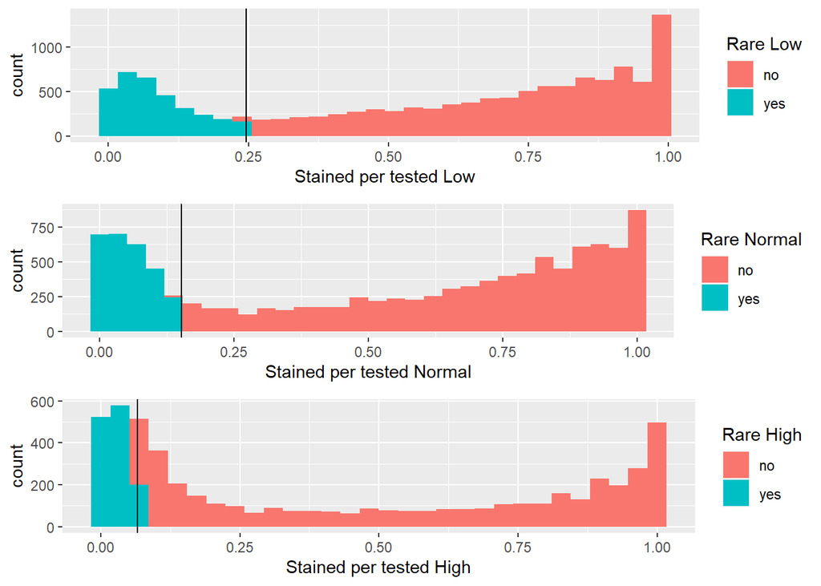

```r
low_plot <- ggplot(low_filter_supp_2, aes(`Stained per tested Low`, fill = `Rare Low`)) +
  geom_histogram(bins = 30) +
  geom_vline(xintercept = quantile(low_filter_supp_2$`Stained per tested Low`, .25))

high_plot <- ggplot(high_filter_supp_2, aes(`Stained per tested High`, fill = `Rare High`)) +
  geom_histogram(bins = 30) +
  geom_vline(xintercept = quantile(high_filter_supp_2$`Stained per tested High`, .25))

normal_plot <- ggplot(normal_filter_supp_2, aes(`Stained per tested Normal`, fill = `Rare Normal`)) +
  geom_histogram(bins = 30) +
  geom_vline(xintercept = quantile(normal_filter_supp_2$`Stained per tested Normal`, .25))




ggarrange(low_plot, normal_plot, high_plot, nrow = 3)
```